# Part II - (Visualization Analysis of GoFordBike-System)

## by (Emmanuel Olorunbogun)

## Investigation Overview

In this presentation, the investigations were focused on characteristics of riders and how they performed in duration of rides in respect to the different:

- **User types**
- **Gender**
- **Hours of the day** and
- **Days of the week**.

## Dataset Overview

After the dataset was cleaned in the exploratory part, its rows were reduced to 175147 and 8 columns. This columns includes:

- bike_id
- user_type
- member_gender
- bike_share_trip_for_all_trip
- duration_min
- Day_of_week
- time
- age

## Key Insight 1: The Gender Proportion of Users in the GoFord Bike System

We have 3 different genders in the whole system.

- The Male users are about **75%** of the total users in the system.
- The Females users are **23%** of that population while the Other gender made up the remaining **2%**.

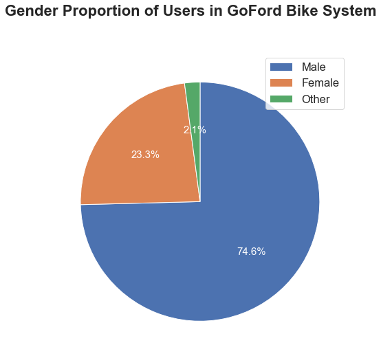

## Key Insight 2: What is the proportion of riders by user type?

- The subscribers were about 90% of the total number of riders in the bike sharing system.
- The customers made up the remaining 10%.

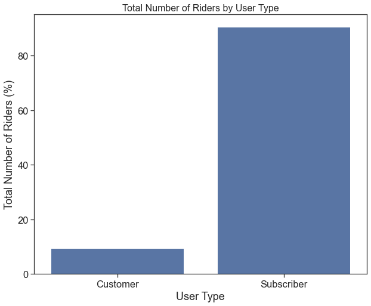

## Key Insight 3: How many minutes does an average trip take?

- Majority of the rides took about 5 to 12.5 minutes.
- It can be said that most of the rides were over a short distance.

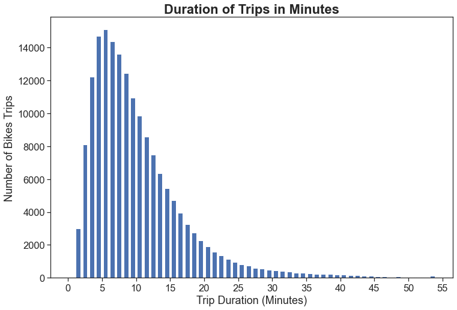

## Key insight 4: What is the daily usage of bikes by user types?

- Thursdays has the highest number of trips taken by both Customers and Subscribers.
- Subscribers have higher usage of bike for every day of the week. This is expected, since the subscribers contribute about 90% of the total population of GoFord bike riders.

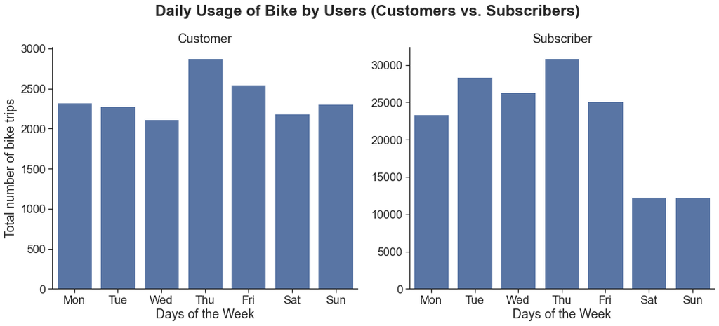

## Key Insight 5: What is the daily average ride time by the user type?

- For the total trips per day, the customers have a higher average ride time compared to the subscribers.
- But both customers and subscribers had an increase in average ride time over the weekend (Saturdays and Sundays).

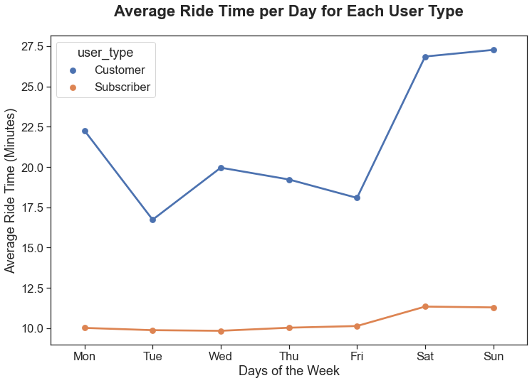

## Key Insight 6: What time of the day is the busiest for riders?

- 8AM and 5PM were the busiest hour of the day.
- This might be a result of the resumption and closing time of riders from their various place of work.

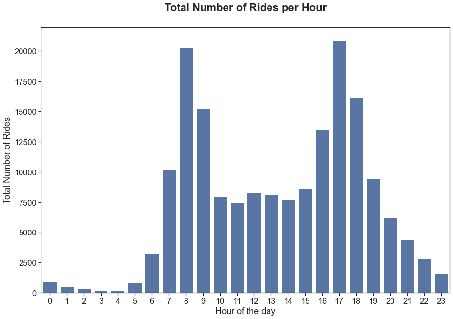